# Reproducible Research: Peer Assessment 1

## Loading and preprocessing the data

1. Load the data (i.e. read.csv())
2. Process/transform the data (if necessary) into a format suitable for your analysis

```r
# Load libraries
library(dplyr)
library(lattice)

# Set working directory
setwd("C:/Program Files/Git/Projects/RepData_PeerAssessment1")

#Load data file
dfActivity = read.csv("activity.csv", stringsAsFactors = FALSE)

#Preprocessing steps for efficient execution
```

## What is mean total number of steps taken per day?

1. Calculate the total number of steps taken per day
2. If you do not understand the difference between a histogram and a barplot, research the difference between them. Make a histogram of the total number of steps taken each day
3. Calculate and report the mean and median of the total number of steps taken per day

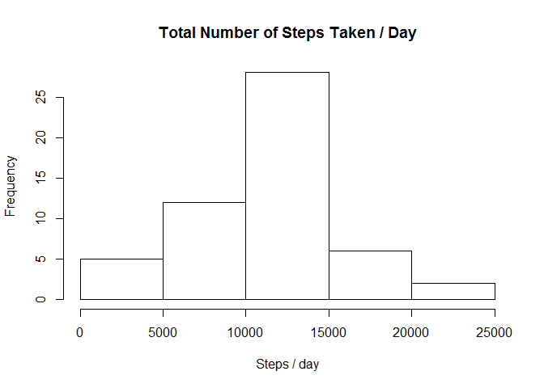

```r
#Calculate the total number of steps taken per day
totalSteps <- aggregate(steps ~ date, dfActivity, sum, na.rm = TRUE)

#Histogram of the total number of steps taken each day
hist(totalSteps$steps, main = "Total Number of Steps Taken / Day",
     xlab = "Steps / day")
```

```r
#Calculate and report the mean and median of the total number of steps taken per day
summary(totalSteps)
```

```
##      date               steps
##  Length:53          Min.   :   41
##  Class :character   1st Qu.: 8841
##  Mode  :character   Median :10765
##                     Mean   :10766
##                     3rd Qu.:13294
##                     Max.   :21194
```

## What is the average daily activity pattern?

1. Make a time series plot (i.e. type = “l”) of the 5-minute interval (x-axis) and the average number of steps taken, averaged across all days (y-axis)
2. Which 5-minute interval, on average across all the days in the dataset, contains the maximum number of steps?

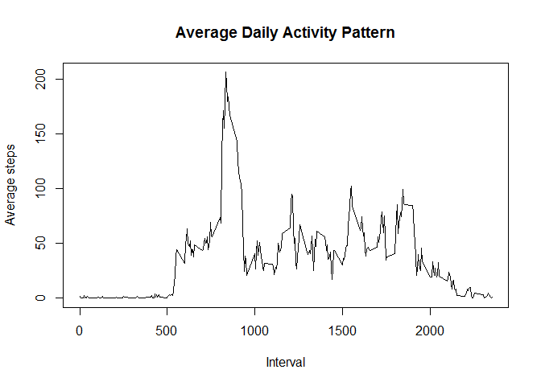

```r
#Time series plot (i.e. type = "l") of the 5-minute interval (x-axis) and the average number of steps taken, averaged across all days (y-axis)
averageSteps <- aggregate(steps ~ interval, dfActivity, mean)
plot(averageSteps$interval, averageSteps$steps, type = "l",
     main = "Average Daily Activity Pattern",
     xlab = "Interval", ylab = "Average steps")
```

```r
#5-minute interval with maximum number of steps
averageSteps[which.max(averageSteps$steps), ]
```

```
##     interval    steps
## 104      835 206.1698
```